# Spaceship_Titanic_final

### Task 1

Import the Libraries

```python
import numpy as np
import pandas as pd
import matplotlib.pyplot as plt
%matplotlib inline
import seaborn as sns
```

Load data

```python
Spaceship_titanic = pd.read_csv("train.csv")
print('Train set shape:', Spaceship_titanic.shape)
Spaceship_titanic.head()
```

```
Train set shape: (8693, 14)
```

|  | PassengerId | HomePlanet | CryoSleep | Cabin | Destination | Age | VIP | RoomService | FoodCourt | ShoppingMall | Spa | VRDeck | Name | Transported |
| --- | --- | --- | --- | --- | --- | --- | --- | --- | --- | --- | --- | --- | --- | --- |
| 0 | 0001_01 | Europa | False | B/0/P | TRAPPIST-1e | 39.0 | False | 0.0 | 0.0 | 0.0 | 0.0 | 0.0 | Maham Ofracculy | False |
| 1 | 0002_01 | Earth | False | F/0/S | TRAPPIST-1e | 24.0 | False | 109.0 | 9.0 | 25.0 | 549.0 | 44.0 | Juanna Vines | True |
| 2 | 0003_01 | Europa | False | A/0/S | TRAPPIST-1e | 58.0 | True | 43.0 | 3576.0 | 0.0 | 6715.0 | 49.0 | Altark Susent | False |
| 3 | 0003_02 | Europa | False | A/0/S | TRAPPIST-1e | 33.0 | False | 0.0 | 1283.0 | 371.0 | 3329.0 | 193.0 | Solam Susent | False |
| 4 | 0004_01 | Earth | False | F/1/S | TRAPPIST-1e | 16.0 | False | 303.0 | 70.0 | 151.0 | 565.0 | 2.0 | Willy Santantines | True |

### Task 2: A description of the dataset

```python
Spaceship_titanic.info()
```

```
<class 'pandas.core.frame.DataFrame'>
RangeIndex: 8693 entries, 0 to 8692
Data columns (total 14 columns):
 #   Column        Non-Null Count  Dtype
---  ------        --------------  -----
 0   PassengerId   8693 non-null   object
 1   HomePlanet    8492 non-null   object
 2   CryoSleep     8476 non-null   object
 3   Cabin         8494 non-null   object
 4   Destination   8511 non-null   object
 5   Age           8514 non-null   float64
 6   VIP           8490 non-null   object
 7   RoomService   8512 non-null   float64
 8   FoodCourt     8510 non-null   float64
 9   ShoppingMall  8485 non-null   float64
 10  Spa           8510 non-null   float64
 11  VRDeck        8505 non-null   float64
 12  Name          8493 non-null   object
 13  Transported   8693 non-null   bool
dtypes: bool(1), float64(6), object(7)
memory usage: 891.5+ KB
```

The Spaceship Titanic was an interstellar passenger liner launched a month ago. With almost 13,000 passengers on board, the vessel set out on its maiden voyage transporting emigrants from our solar system to three newly habitable exoplanets orbiting nearby stars.

While rounding Alpha Centauri en route to its first destination—the torrid 55 Cancri E—the unwary Spaceship Titanic collided with a spacetime anomaly hidden within a dust cloud. Sadly, it met a similar fate as its namesake from 1000 years before. Though the ship stayed intact, almost half of the passengers were transported to an alternate dimension!

Anyway, just try to predict which passengers were transported by the anomaly using records recovered from the dataset above.

```python
Spaceship_titanic.columns
```

```
Index(['PassengerId', 'HomePlanet', 'CryoSleep', 'Cabin', 'Destination', 'Age',
       'VIP', 'RoomService', 'FoodCourt', 'ShoppingMall', 'Spa', 'VRDeck',
       'Name', 'Transported'],
      dtype='object')
```

Explanation of the features

PassengerId - A unique Id for each passenger. Each Id takes the form gggg_pp where gggg indicates a group the passenger is travelling with and pp is their number within the group. People in a group are often family members, but not always.

HomePlanet - The planet the passenger departed from, typically their planet of permanent residence.

CryoSleep - Indicates whether the passenger elected to be put into suspended animation for the duration of the voyage. Passengers in cryosleep are confined to their cabins.

Cabin - The cabin number where the passenger is staying. Takes the form deck/num/side, where side can be either P for Port or S for Starboard.

Destination - The planet the passenger will be debarking to.

Age - The age of the passenger.

VIP - Whether the passenger has paid for special VIP service during the voyage.

RoomService, FoodCourt, ShoppingMall, Spa, VRDeck - Amount the passenger has billed at each of the Spaceship Titanic's many luxury amenities.

Name - The first and last names of the passenger.

Transported - Whether the passenger was transported to another dimension. This is the target, the column you are trying to predict.

```python
#count the number of unique values in dataframe
Spaceship_titanic.nunique()
```

```
PassengerId     8693
HomePlanet         3
CryoSleep          2
Cabin           6560
Destination        3
Age               80
VIP                2
RoomService     1273
FoodCourt       1507
ShoppingMall    1115
Spa             1327
VRDeck          1306
Name            8473
Transported        2
dtype: int64
```

```python
Spaceship_titanic.dtypes
```

```
PassengerId      object
HomePlanet       object
CryoSleep        object
Cabin            object
Destination      object
Age             float64
VIP              object
RoomService     float64
FoodCourt       float64
ShoppingMall    float64
Spa             float64
VRDeck          float64
Name             object
Transported        bool
dtype: object
```

6 numerical features: Age, RoomService, FoodCourt, ShoppingMall, Spa, VRDeck 4 categorical features: HomePlanet, CryoSleep, Destination, VIP 3 text features: Name, Cabin, PassengerId

Need to transform the data to be numerical

```
array([[<AxesSubplot:title={'center':'Age'}>,
        <AxesSubplot:title={'center':'RoomService'}>],
       [<AxesSubplot:title={'center':'FoodCourt'}>,
        <AxesSubplot:title={'center':'ShoppingMall'}>],
       [<AxesSubplot:title={'center':'Spa'}>,
        <AxesSubplot:title={'center':'VRDeck'}>]], dtype=object)
```

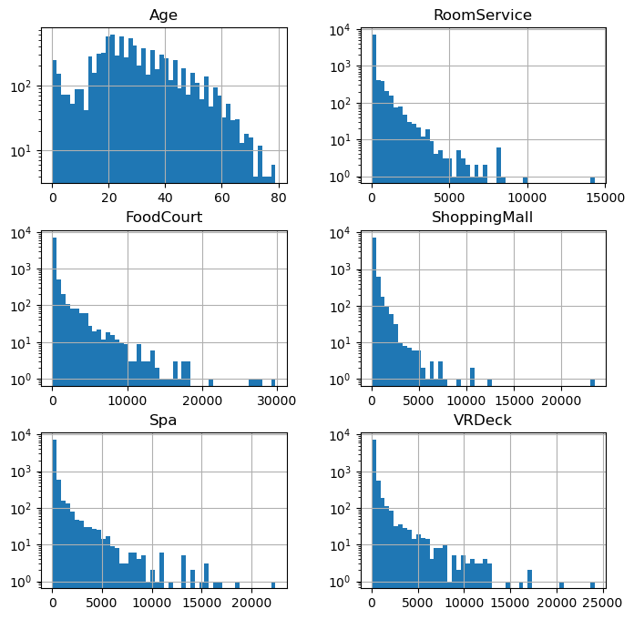

```python
'''
select data type = float64 values and plot these data histograms
figsize sets the size of the figure
bins sets the number of bins in each histogram
log=True sets the y-axis to a logarithmic scale
'''
Spaceship_titanic[Spaceship_titanic.dtypes[(Spaceship_titanic.dtypes=="float64")]
             .index.values].hist(figsize=[8,8], bins= 50, log = True)
```

### Task 3: Data Preprocessing

Convert category to numeric

```python
Spaceship_titanic['Cabin'] = Spaceship_titanic['Cabin'].apply(lambda x:str(x).split("/")[0])
```

```python
#The LabelEncoder class in scikit-learn is used to encode categorical variables with integer values.
from sklearn import preprocessing
label_encoder = preprocessing.LabelEncoder()

Spaceship_titanic["HomePlanet"] = label_encoder.fit_transform(Spaceship_titanic["HomePlanet"])
Spaceship_titanic["CryoSleep"] = label_encoder.fit_transform(Spaceship_titanic["CryoSleep"])
Spaceship_titanic["Cabin"] = label_encoder.fit_transform(Spaceship_titanic["Cabin"])
Spaceship_titanic["Destination"] = label_encoder.fit_transform(Spaceship_titanic["Destination"])
Spaceship_titanic["VIP"] = label_encoder.fit_transform(Spaceship_titanic["VIP"])

Spaceship_titanic.head()
```

|  | PassengerId | HomePlanet | CryoSleep | Cabin | Destination | Age | VIP | RoomService | FoodCourt | ShoppingMall | Spa | VRDeck | Name | Transported |
| --- | --- | --- | --- | --- | --- | --- | --- | --- | --- | --- | --- | --- | --- | --- |
| 0 | 0001_01 | 1 | 0 | 1 | 2 | 39.0 | 0 | 0.0 | 0.0 | 0.0 | 0.0 | 0.0 | Maham Ofracculy | False |
| 1 | 0002_01 | 0 | 0 | 5 | 2 | 24.0 | 0 | 109.0 | 9.0 | 25.0 | 549.0 | 44.0 | Juanna Vines | True |
| 2 | 0003_01 | 1 | 0 | 0 | 2 | 58.0 | 1 | 43.0 | 3576.0 | 0.0 | 6715.0 | 49.0 | Altark Susent | False |
| 3 | 0003_02 | 1 | 0 | 0 | 2 | 33.0 | 0 | 0.0 | 1283.0 | 371.0 | 3329.0 | 193.0 | Solam Susent | False |
| 4 | 0004_01 | 0 | 0 | 5 | 2 | 16.0 | 0 | 303.0 | 70.0 | 151.0 | 565.0 | 2.0 | Willy Santantines | True |

Missing Values

```python
na_cols=Spaceship_titanic.columns[Spaceship_titanic.isna().any()].tolist()


missing_values=pd.DataFrame(Spaceship_titanic[na_cols].isna().sum(), columns=['Number_missing'])
missing_values['Percentage_missing']=np.round(100*missing_values['Number_missing']/len(Spaceship_titanic),3)
missing_values
```

|  | Number_missing | Percentage_missing |
| --- | --- | --- |
| Age | 179 | 2.059 |
| RoomService | 181 | 2.082 |
| FoodCourt | 183 | 2.105 |
| ShoppingMall | 208 | 2.393 |
| Spa | 183 | 2.105 |
| VRDeck | 188 | 2.163 |
| Name | 200 | 2.301 |

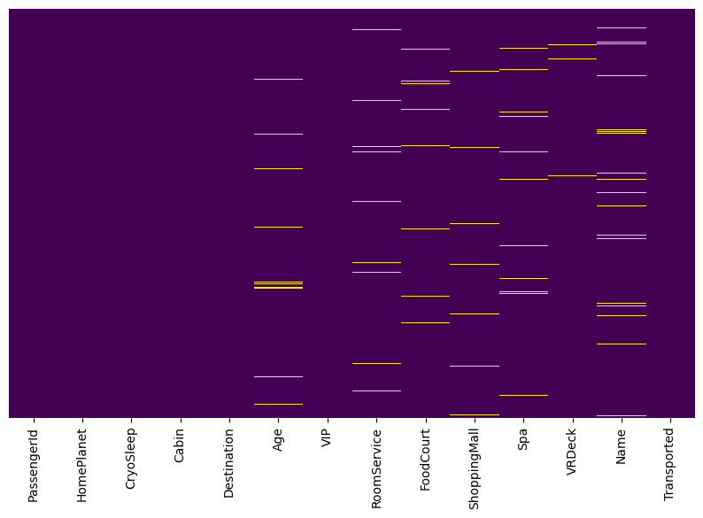

```python
plt.figure(figsize=(10,6))
sns.heatmap(Spaceship_titanic.isna(), cbar=False, cmap='viridis', yticklabels=False)
```

Dealing with missing values:

```python
from sklearn.experimental import enable_iterative_imputer
from sklearn.impute import IterativeImputer
from sklearn.impute import SimpleImputer
from sklearn.preprocessing import StandardScaler
from sklearn.preprocessing import OneHotEncoder
```

OneHotEncoding

```python
ohe = OneHotEncoder(sparse=False, drop='first', dtype=np.int64)
ohe = ohe.fit(Spaceship_titanic[['HomePlanet','CryoSleep', 'Cabin', 'Destination','VIP']])
ohe_features = ohe.get_feature_names(['HomePlanet','CryoSleep', 'Cabin', 'Destination','VIP'])
Spaceship_titanic_categorical = ohe.transform(Spaceship_titanic[['HomePlanet','CryoSleep', 'Cabin', 'Destination','VIP']])
```

Filling median for numerical features Filling most_frequent for categorical features

```python
#strategy='median' specifies that the median value of the non-missing values in each column should be used to impute missing values
imp = SimpleImputer(missing_values = np.nan, strategy='median')
Spaceship_titanic_numerical = Spaceship_titanic[['Age','RoomService','FoodCourt','ShoppingMall','Spa','VRDeck']]
imp.fit(Spaceship_titanic_numerical)
Spaceship_titanic_numerical_transform = imp.transform(Spaceship_titanic_numerical)
Spaceship_titanic_numerical_transform.dtype
```

```
dtype('float64')
```

```python
imp2 = SimpleImputer(missing_values = np.nan, strategy='most_frequent')
Spaceship_titanic_categorical =Spaceship_titanic[['HomePlanet','CryoSleep', 'Cabin', 'Destination','VIP']]
imp2.fit(Spaceship_titanic_categorical)
Spaceship_titanic_categorical_transform = imp2.transform(Spaceship_titanic_categorical)
Spaceship_titanic_categorical_transform = Spaceship_titanic_categorical_transform.astype("float64")
Spaceship_titanic_categorical_transform.dtype
```

```
dtype('float64')
```

```python
# reshape the array into dataframe
Spaceship_titanic_numerical_transform_df = pd.DataFrame(Spaceship_titanic_numerical_transform.reshape(8693,6))

Spaceship_titanic_categorical_transform_df = pd.DataFrame(Spaceship_titanic_categorical_transform.reshape(8693,5))
```

```python
Spaceship_titanic_categorical_transform_df
```

|  | 0 | 1 | 2 | 3 | 4 |
| --- | --- | --- | --- | --- | --- |
| 0 | 1.0 | 0.0 | 1.0 | 2.0 | 0.0 |
| 1 | 0.0 | 0.0 | 5.0 | 2.0 | 0.0 |
| 2 | 1.0 | 0.0 | 0.0 | 2.0 | 1.0 |
| 3 | 1.0 | 0.0 | 0.0 | 2.0 | 0.0 |
| 4 | 0.0 | 0.0 | 5.0 | 2.0 | 0.0 |
| ... | ... | ... | ... | ... | ... |
| 8688 | 1.0 | 0.0 | 0.0 | 0.0 | 1.0 |
| 8689 | 0.0 | 1.0 | 6.0 | 1.0 | 0.0 |
| 8690 | 0.0 | 0.0 | 6.0 | 2.0 | 0.0 |
| 8691 | 1.0 | 0.0 | 4.0 | 0.0 | 0.0 |
| 8692 | 1.0 | 0.0 | 4.0 | 2.0 | 0.0 |

8693 rows × 5 columns

```python
Spaceship_titanic_numerical_transform_df
```

|  | 0 | 1 | 2 | 3 | 4 | 5 |
| --- | --- | --- | --- | --- | --- | --- |
| 0 | 39.0 | 0.0 | 0.0 | 0.0 | 0.0 | 0.0 |
| 1 | 24.0 | 109.0 | 9.0 | 25.0 | 549.0 | 44.0 |
| 2 | 58.0 | 43.0 | 3576.0 | 0.0 | 6715.0 | 49.0 |
| 3 | 33.0 | 0.0 | 1283.0 | 371.0 | 3329.0 | 193.0 |
| 4 | 16.0 | 303.0 | 70.0 | 151.0 | 565.0 | 2.0 |
| ... | ... | ... | ... | ... | ... | ... |
| 8688 | 41.0 | 0.0 | 6819.0 | 0.0 | 1643.0 | 74.0 |
| 8689 | 18.0 | 0.0 | 0.0 | 0.0 | 0.0 | 0.0 |
| 8690 | 26.0 | 0.0 | 0.0 | 1872.0 | 1.0 | 0.0 |
| 8691 | 32.0 | 0.0 | 1049.0 | 0.0 | 353.0 | 3235.0 |
| 8692 | 44.0 | 126.0 | 4688.0 | 0.0 | 0.0 | 12.0 |

8693 rows × 6 columns

combine numerical columns and categorical columns

```python
feature_matrix = pd.concat([Spaceship_titanic_categorical_transform_df,Spaceship_titanic_numerical_transform_df],axis=1)
```

```python
feature_matrix.columns = ['HomePlanet','CryoSleep', 'Cabin', 'Destination','VIP','Age','RoomService','FoodCourt','ShoppingMall','Spa','VRDeck']
```

```python
feature_matrix
```

|  | HomePlanet | CryoSleep | Cabin | Destination | VIP | Age | RoomService | FoodCourt | ShoppingMall | Spa | VRDeck |
| --- | --- | --- | --- | --- | --- | --- | --- | --- | --- | --- | --- |
| 0 | 1.0 | 0.0 | 1.0 | 2.0 | 0.0 | 39.0 | 0.0 | 0.0 | 0.0 | 0.0 | 0.0 |
| 1 | 0.0 | 0.0 | 5.0 | 2.0 | 0.0 | 24.0 | 109.0 | 9.0 | 25.0 | 549.0 | 44.0 |
| 2 | 1.0 | 0.0 | 0.0 | 2.0 | 1.0 | 58.0 | 43.0 | 3576.0 | 0.0 | 6715.0 | 49.0 |
| 3 | 1.0 | 0.0 | 0.0 | 2.0 | 0.0 | 33.0 | 0.0 | 1283.0 | 371.0 | 3329.0 | 193.0 |
| 4 | 0.0 | 0.0 | 5.0 | 2.0 | 0.0 | 16.0 | 303.0 | 70.0 | 151.0 | 565.0 | 2.0 |
| ... | ... | ... | ... | ... | ... | ... | ... | ... | ... | ... | ... |
| 8688 | 1.0 | 0.0 | 0.0 | 0.0 | 1.0 | 41.0 | 0.0 | 6819.0 | 0.0 | 1643.0 | 74.0 |
| 8689 | 0.0 | 1.0 | 6.0 | 1.0 | 0.0 | 18.0 | 0.0 | 0.0 | 0.0 | 0.0 | 0.0 |
| 8690 | 0.0 | 0.0 | 6.0 | 2.0 | 0.0 | 26.0 | 0.0 | 0.0 | 1872.0 | 1.0 | 0.0 |
| 8691 | 1.0 | 0.0 | 4.0 | 0.0 | 0.0 | 32.0 | 0.0 | 1049.0 | 0.0 | 353.0 | 3235.0 |
| 8692 | 1.0 | 0.0 | 4.0 | 2.0 | 0.0 | 44.0 | 126.0 | 4688.0 | 0.0 | 0.0 | 12.0 |

8693 rows × 11 columns

split column 'Transported' as target

```python
Spaceship_titanic_target = Spaceship_titanic['Transported']
Spaceship_titanic_target
```

```
0       False
1        True
2       False
3       False
4        True
        ...
8688    False
8689    False
8690     True
8691    False
8692     True
Name: Transported, Length: 8693, dtype: bool
```

```python
Spaceship_titanic_training = pd.concat([feature_matrix,Spaceship_titanic_target],axis=1)
Spaceship_titanic_training
```

|  | HomePlanet | CryoSleep | Cabin | Destination | VIP | Age | RoomService | FoodCourt | ShoppingMall | Spa | VRDeck | Transported |
| --- | --- | --- | --- | --- | --- | --- | --- | --- | --- | --- | --- | --- |
| 0 | 1.0 | 0.0 | 1.0 | 2.0 | 0.0 | 39.0 | 0.0 | 0.0 | 0.0 | 0.0 | 0.0 | False |
| 1 | 0.0 | 0.0 | 5.0 | 2.0 | 0.0 | 24.0 | 109.0 | 9.0 | 25.0 | 549.0 | 44.0 | True |
| 2 | 1.0 | 0.0 | 0.0 | 2.0 | 1.0 | 58.0 | 43.0 | 3576.0 | 0.0 | 6715.0 | 49.0 | False |
| 3 | 1.0 | 0.0 | 0.0 | 2.0 | 0.0 | 33.0 | 0.0 | 1283.0 | 371.0 | 3329.0 | 193.0 | False |
| 4 | 0.0 | 0.0 | 5.0 | 2.0 | 0.0 | 16.0 | 303.0 | 70.0 | 151.0 | 565.0 | 2.0 | True |
| ... | ... | ... | ... | ... | ... | ... | ... | ... | ... | ... | ... | ... |
| 8688 | 1.0 | 0.0 | 0.0 | 0.0 | 1.0 | 41.0 | 0.0 | 6819.0 | 0.0 | 1643.0 | 74.0 | False |
| 8689 | 0.0 | 1.0 | 6.0 | 1.0 | 0.0 | 18.0 | 0.0 | 0.0 | 0.0 | 0.0 | 0.0 | False |
| 8690 | 0.0 | 0.0 | 6.0 | 2.0 | 0.0 | 26.0 | 0.0 | 0.0 | 1872.0 | 1.0 | 0.0 | True |
| 8691 | 1.0 | 0.0 | 4.0 | 0.0 | 0.0 | 32.0 | 0.0 | 1049.0 | 0.0 | 353.0 | 3235.0 | False |
| 8692 | 1.0 | 0.0 | 4.0 | 2.0 | 0.0 | 44.0 | 126.0 | 4688.0 | 0.0 | 0.0 | 12.0 | True |

8693 rows × 12 columns

MinMaxScaler scales down all the features to a same range

```python
#scale the numerical features to a given range
from sklearn.preprocessing import MinMaxScaler
min_max = MinMaxScaler()
X_train_minmax = min_max.fit_transform(Spaceship_titanic_numerical_transform_df)
X_train_minmax
```

```
array([[4.93670886e-01, 0.00000000e+00, 0.00000000e+00, 0.00000000e+00,
        0.00000000e+00, 0.00000000e+00],
       [3.03797468e-01, 7.60801284e-03, 3.01881729e-04, 1.06419207e-03,
        2.45001785e-02, 1.82322960e-03],
       [7.34177215e-01, 3.00132617e-03, 1.19947674e-01, 0.00000000e+00,
        2.99669761e-01, 2.03041478e-03],
       ...,
       [3.29113924e-01, 0.00000000e+00, 0.00000000e+00, 7.96867019e-02,
        4.46269190e-05, 0.00000000e+00],
       [4.05063291e-01, 0.00000000e+00, 3.51859927e-02, 0.00000000e+00,
        1.57533024e-02, 1.34048813e-01],
       [5.56962025e-01, 8.79458365e-03, 1.57246839e-01, 0.00000000e+00,
        0.00000000e+00, 4.97244437e-04]])
```

```python
X_train_minmax = pd.DataFrame(X_train_minmax.reshape(8693,6))
Spaceship_titanic_minmax_training = pd.concat([X_train_minmax,Spaceship_titanic_categorical_transform_df],axis=1)
Spaceship_titanic_minmax_training = pd.concat([Spaceship_titanic_minmax_training,Spaceship_titanic_target],axis=1)
Spaceship_titanic_minmax_training
```

|  | 0 | 1 | 2 | 3 | 4 | 5 | 0 | 1 | 2 | 3 | 4 | Transported |
| --- | --- | --- | --- | --- | --- | --- | --- | --- | --- | --- | --- | --- |
| 0 | 0.493671 | 0.000000 | 0.000000 | 0.000000 | 0.000000 | 0.000000 | 1.0 | 0.0 | 1.0 | 2.0 | 0.0 | False |
| 1 | 0.303797 | 0.007608 | 0.000302 | 0.001064 | 0.024500 | 0.001823 | 0.0 | 0.0 | 5.0 | 2.0 | 0.0 | True |
| 2 | 0.734177 | 0.003001 | 0.119948 | 0.000000 | 0.299670 | 0.002030 | 1.0 | 0.0 | 0.0 | 2.0 | 1.0 | False |
| 3 | 0.417722 | 0.000000 | 0.043035 | 0.015793 | 0.148563 | 0.007997 | 1.0 | 0.0 | 0.0 | 2.0 | 0.0 | False |
| 4 | 0.202532 | 0.021149 | 0.002348 | 0.006428 | 0.025214 | 0.000083 | 0.0 | 0.0 | 5.0 | 2.0 | 0.0 | True |
| ... | ... | ... | ... | ... | ... | ... | ... | ... | ... | ... | ... | ... |
| 8688 | 0.518987 | 0.000000 | 0.228726 | 0.000000 | 0.073322 | 0.003066 | 1.0 | 0.0 | 0.0 | 0.0 | 1.0 | False |
| 8689 | 0.227848 | 0.000000 | 0.000000 | 0.000000 | 0.000000 | 0.000000 | 0.0 | 1.0 | 6.0 | 1.0 | 0.0 | False |
| 8690 | 0.329114 | 0.000000 | 0.000000 | 0.079687 | 0.000045 | 0.000000 | 0.0 | 0.0 | 6.0 | 2.0 | 0.0 | True |
| 8691 | 0.405063 | 0.000000 | 0.035186 | 0.000000 | 0.015753 | 0.134049 | 1.0 | 0.0 | 4.0 | 0.0 | 0.0 | False |
| 8692 | 0.556962 | 0.008795 | 0.157247 | 0.000000 | 0.000000 | 0.000497 | 1.0 | 0.0 | 4.0 | 2.0 | 0.0 | True |

8693 rows × 12 columns

```python
Spaceship_titanic_minmax_training.columns = ['Age','RoomService','FoodCourt','ShoppingMall','Spa','VRDeck', 'HomePlanet','CryoSleep', 'Cabin', 'Destination','VIP','Transported']
Spaceship_titanic_minmax_training
```

|  | Age | RoomService | FoodCourt | ShoppingMall | Spa | VRDeck | HomePlanet | CryoSleep | Cabin | Destination | VIP | Transported |
| --- | --- | --- | --- | --- | --- | --- | --- | --- | --- | --- | --- | --- |
| 0 | 0.493671 | 0.000000 | 0.000000 | 0.000000 | 0.000000 | 0.000000 | 1.0 | 0.0 | 1.0 | 2.0 | 0.0 | False |
| 1 | 0.303797 | 0.007608 | 0.000302 | 0.001064 | 0.024500 | 0.001823 | 0.0 | 0.0 | 5.0 | 2.0 | 0.0 | True |
| 2 | 0.734177 | 0.003001 | 0.119948 | 0.000000 | 0.299670 | 0.002030 | 1.0 | 0.0 | 0.0 | 2.0 | 1.0 | False |
| 3 | 0.417722 | 0.000000 | 0.043035 | 0.015793 | 0.148563 | 0.007997 | 1.0 | 0.0 | 0.0 | 2.0 | 0.0 | False |
| 4 | 0.202532 | 0.021149 | 0.002348 | 0.006428 | 0.025214 | 0.000083 | 0.0 | 0.0 | 5.0 | 2.0 | 0.0 | True |
| ... | ... | ... | ... | ... | ... | ... | ... | ... | ... | ... | ... | ... |
| 8688 | 0.518987 | 0.000000 | 0.228726 | 0.000000 | 0.073322 | 0.003066 | 1.0 | 0.0 | 0.0 | 0.0 | 1.0 | False |
| 8689 | 0.227848 | 0.000000 | 0.000000 | 0.000000 | 0.000000 | 0.000000 | 0.0 | 1.0 | 6.0 | 1.0 | 0.0 | False |
| 8690 | 0.329114 | 0.000000 | 0.000000 | 0.079687 | 0.000045 | 0.000000 | 0.0 | 0.0 | 6.0 | 2.0 | 0.0 | True |
| 8691 | 0.405063 | 0.000000 | 0.035186 | 0.000000 | 0.015753 | 0.134049 | 1.0 | 0.0 | 4.0 | 0.0 | 0.0 | False |
| 8692 | 0.556962 | 0.008795 | 0.157247 | 0.000000 | 0.000000 | 0.000497 | 1.0 | 0.0 | 4.0 | 2.0 | 0.0 | True |

8693 rows × 12 columns

```python
from sklearn.model_selection import train_test_split
from sklearn.linear_model import LogisticRegression
from sklearn.metrics import confusion_matrix
from sklearn.pipeline import make_pipeline
from sklearn.preprocessing import StandardScaler
from sklearn.metrics import accuracy_score
from sklearn.model_selection import RepeatedStratifiedKFold, cross_val_score
```

```python
X = Spaceship_titanic_minmax_training.drop('Transported',axis=1)
y = Spaceship_titanic_minmax_training['Transported']
```

```python
X_train, X_test, y_train, y_test = train_test_split(X, y, test_size=0.20, random_state=0)
```

LogisticRegression of Spaceship data after data preprocessing

```python
lr = LogisticRegression(random_state=0, max_iter=50).fit(X_train, y_train)
```

```python
predictions_lr = lr.predict(X_test)
predictions_lr
```

```
array([False,  True, False, ...,  True, False, False])
```

```python
print(confusion_matrix(y_test,predictions_lr))
```

```
[[680 183]
 [248 628]]
```

```python
lr.score(X_test, y_test)
```

```
0.7521564117308798
```

(GridSearchCV) LogisticRegression of Spaceship data after data preprocessing

```python
from sklearn.model_selection import GridSearchCV
param_grid_lr = {'C': [0.1,1, 10], 'solver': ['newton-cg','lbfgs','liblinear','sag']}
```

```python
grid = GridSearchCV(LogisticRegression(),param_grid_lr,refit=True,verbose=3)
```

```python
grid.fit(X_train,y_train)
```

```
Fitting 5 folds for each of 12 candidates, totalling 60 fits
[CV 1/5] END ...........C=0.1, solver=newton-cg;, score=0.733 total time=   0.0s
[CV 2/5] END ...........C=0.1, solver=newton-cg;, score=0.728 total time=   0.0s
[CV 3/5] END ...........C=0.1, solver=newton-cg;, score=0.752 total time=   0.0s
[CV 4/5] END ...........C=0.1, solver=newton-cg;, score=0.731 total time=   0.0s
[CV 5/5] END ...........C=0.1, solver=newton-cg;, score=0.734 total time=   0.0s
[CV 1/5] END ...............C=0.1, solver=lbfgs;, score=0.733 total time=   0.0s
[CV 2/5] END ...............C=0.1, solver=lbfgs;, score=0.728 total time=   0.0s
[CV 3/5] END ...............C=0.1, solver=lbfgs;, score=0.752 total time=   0.0s
[CV 4/5] END ...............C=0.1, solver=lbfgs;, score=0.731 total time=   0.0s
[CV 5/5] END ...............C=0.1, solver=lbfgs;, score=0.734 total time=   0.0s
[CV 1/5] END ...........C=0.1, solver=liblinear;, score=0.733 total time=   0.0s
[CV 2/5] END ...........C=0.1, solver=liblinear;, score=0.727 total time=   0.0s
[CV 3/5] END ...........C=0.1, solver=liblinear;, score=0.753 total time=   0.0s
[CV 4/5] END ...........C=0.1, solver=liblinear;, score=0.730 total time=   0.0s
[CV 5/5] END ...........C=0.1, solver=liblinear;, score=0.733 total time=   0.0s
[CV 1/5] END .................C=0.1, solver=sag;, score=0.733 total time=   0.0s
[CV 2/5] END .................C=0.1, solver=sag;, score=0.728 total time=   0.0s
[CV 3/5] END .................C=0.1, solver=sag;, score=0.752 total time=   0.0s
[CV 4/5] END .................C=0.1, solver=sag;, score=0.731 total time=   0.0s
[CV 5/5] END .................C=0.1, solver=sag;, score=0.734 total time=   0.0s
[CV 1/5] END .............C=1, solver=newton-cg;, score=0.756 total time=   0.0s
[CV 2/5] END .............C=1, solver=newton-cg;, score=0.753 total time=   0.0s
[CV 3/5] END .............C=1, solver=newton-cg;, score=0.771 total time=   0.0s
[CV 4/5] END .............C=1, solver=newton-cg;, score=0.756 total time=   0.0s
[CV 5/5] END .............C=1, solver=newton-cg;, score=0.755 total time=   0.0s
[CV 1/5] END .................C=1, solver=lbfgs;, score=0.756 total time=   0.0s
[CV 2/5] END .................C=1, solver=lbfgs;, score=0.753 total time=   0.0s
[CV 3/5] END .................C=1, solver=lbfgs;, score=0.771 total time=   0.0s
[CV 4/5] END .................C=1, solver=lbfgs;, score=0.756 total time=   0.0s
[CV 5/5] END .................C=1, solver=lbfgs;, score=0.755 total time=   0.0s
[CV 1/5] END .............C=1, solver=liblinear;, score=0.756 total time=   0.0s
[CV 2/5] END .............C=1, solver=liblinear;, score=0.754 total time=   0.0s
[CV 3/5] END .............C=1, solver=liblinear;, score=0.771 total time=   0.0s
[CV 4/5] END .............C=1, solver=liblinear;, score=0.756 total time=   0.0s
[CV 5/5] END .............C=1, solver=liblinear;, score=0.755 total time=   0.0s
[CV 1/5] END ...................C=1, solver=sag;, score=0.756 total time=   0.0s
[CV 2/5] END ...................C=1, solver=sag;, score=0.753 total time=   0.0s
[CV 3/5] END ...................C=1, solver=sag;, score=0.771 total time=   0.0s
[CV 4/5] END ...................C=1, solver=sag;, score=0.756 total time=   0.0s
[CV 5/5] END ...................C=1, solver=sag;, score=0.755 total time=   0.0s
[CV 1/5] END ............C=10, solver=newton-cg;, score=0.781 total time=   0.0s
[CV 2/5] END ............C=10, solver=newton-cg;, score=0.776 total time=   0.0s
[CV 3/5] END ............C=10, solver=newton-cg;, score=0.780 total time=   0.0s
[CV 4/5] END ............C=10, solver=newton-cg;, score=0.774 total time=   0.0s
[CV 5/5] END ............C=10, solver=newton-cg;, score=0.778 total time=   0.0s
```

```
[CV 1/5] END ................C=10, solver=lbfgs;, score=0.783 total time=   0.0s
[CV 2/5] END ................C=10, solver=lbfgs;, score=0.776 total time=   0.0s
[CV 3/5] END ................C=10, solver=lbfgs;, score=0.780 total time=   0.0s
```

```
[CV 4/5] END ................C=10, solver=lbfgs;, score=0.774 total time=   0.0s
[CV 5/5] END ................C=10, solver=lbfgs;, score=0.778 total time=   0.0s
[CV 1/5] END ............C=10, solver=liblinear;, score=0.781 total time=   0.0s
[CV 2/5] END ............C=10, solver=liblinear;, score=0.776 total time=   0.0s
[CV 3/5] END ............C=10, solver=liblinear;, score=0.780 total time=   0.0s
[CV 4/5] END ............C=10, solver=liblinear;, score=0.774 total time=   0.0s
[CV 5/5] END ............C=10, solver=liblinear;, score=0.778 total time=   0.0s
```

```
[CV 1/5] END ..................C=10, solver=sag;, score=0.777 total time=   0.1s
[CV 2/5] END ..................C=10, solver=sag;, score=0.776 total time=   0.0s
```

```
[CV 3/5] END ..................C=10, solver=sag;, score=0.780 total time=   0.1s
[CV 4/5] END ..................C=10, solver=sag;, score=0.771 total time=   0.0s
```

```
[CV 5/5] END ..................C=10, solver=sag;, score=0.776 total time=   0.0s
```

```
GridSearchCV(estimator=LogisticRegression(),
             param_grid={'C': [0.1, 1, 10],
                         'solver': ['newton-cg', 'lbfgs', 'liblinear', 'sag']},
             verbose=3)
```

```python
grid.best_params_
```

```
{'C': 10, 'solver': 'lbfgs'}
```

```python
grid_predictions_lr = grid.predict(X_test)
```

```python
print(confusion_matrix(y_test,grid_predictions_lr))
grid.score(X_test, y_test)
```

```
[[639 224]
 [185 691]]
```

```
0.7648073605520413
```

DecisionTreeClassifier of Spaceship data after data preprocessing

```python
from sklearn.tree import DecisionTreeClassifier
```

```python
DT_clf = DecisionTreeClassifier()
```

```python
DT_clf.fit(X_train,y_train)
```

```
DecisionTreeClassifier()
```

```python
DTC_predictions = DT_clf.predict(X_test)
```

```python
print(confusion_matrix(y_test,DTC_predictions))
```

```
[[585 278]
 [194 682]]
```

```python
DT_clf.score(X_test, y_test)
```

```
0.7285796434732605
```

(GridSearchCV) DecisionTreeClassifier of Spaceship data after data preprocessing

```python
param_grid_DT = {'min_impurity_decrease':[0.1,0.2,0.5], 'criterion':['gini','entropy'], 'max_depth': [30,60,100]}
grid = GridSearchCV(DecisionTreeClassifier(),param_grid_DT,refit=True,verbose=3)
```

```python
grid.fit(X_train,y_train)
```

```
Fitting 5 folds for each of 18 candidates, totalling 90 fits
[CV 1/5] END criterion=gini, max_depth=30, min_impurity_decrease=0.1;, score=0.710 total time=   0.0s
[CV 2/5] END criterion=gini, max_depth=30, min_impurity_decrease=0.1;, score=0.712 total time=   0.0s
[CV 3/5] END criterion=gini, max_depth=30, min_impurity_decrease=0.1;, score=0.729 total time=   0.0s
[CV 4/5] END criterion=gini, max_depth=30, min_impurity_decrease=0.1;, score=0.714 total time=   0.0s
[CV 5/5] END criterion=gini, max_depth=30, min_impurity_decrease=0.1;, score=0.727 total time=   0.0s
[CV 1/5] END criterion=gini, max_depth=30, min_impurity_decrease=0.2;, score=0.503 total time=   0.0s
[CV 2/5] END criterion=gini, max_depth=30, min_impurity_decrease=0.2;, score=0.503 total time=   0.0s
[CV 3/5] END criterion=gini, max_depth=30, min_impurity_decrease=0.2;, score=0.504 total time=   0.0s
[CV 4/5] END criterion=gini, max_depth=30, min_impurity_decrease=0.2;, score=0.504 total time=   0.0s
[CV 5/5] END criterion=gini, max_depth=30, min_impurity_decrease=0.2;, score=0.504 total time=   0.0s
[CV 1/5] END criterion=gini, max_depth=30, min_impurity_decrease=0.5;, score=0.503 total time=   0.0s
[CV 2/5] END criterion=gini, max_depth=30, min_impurity_decrease=0.5;, score=0.503 total time=   0.0s
[CV 3/5] END criterion=gini, max_depth=30, min_impurity_decrease=0.5;, score=0.504 total time=   0.0s
[CV 4/5] END criterion=gini, max_depth=30, min_impurity_decrease=0.5;, score=0.504 total time=   0.0s
[CV 5/5] END criterion=gini, max_depth=30, min_impurity_decrease=0.5;, score=0.504 total time=   0.0s
[CV 1/5] END criterion=gini, max_depth=60, min_impurity_decrease=0.1;, score=0.710 total time=   0.0s
[CV 2/5] END criterion=gini, max_depth=60, min_impurity_decrease=0.1;, score=0.712 total time=   0.0s
[CV 3/5] END criterion=gini, max_depth=60, min_impurity_decrease=0.1;, score=0.729 total time=   0.0s
[CV 4/5] END criterion=gini, max_depth=60, min_impurity_decrease=0.1;, score=0.714 total time=   0.0s
[CV 5/5] END criterion=gini, max_depth=60, min_impurity_decrease=0.1;, score=0.727 total time=   0.0s
[CV 1/5] END criterion=gini, max_depth=60, min_impurity_decrease=0.2;, score=0.503 total time=   0.0s
[CV 2/5] END criterion=gini, max_depth=60, min_impurity_decrease=0.2;, score=0.503 total time=   0.0s
[CV 3/5] END criterion=gini, max_depth=60, min_impurity_decrease=0.2;, score=0.504 total time=   0.0s
[CV 4/5] END criterion=gini, max_depth=60, min_impurity_decrease=0.2;, score=0.504 total time=   0.0s
[CV 5/5] END criterion=gini, max_depth=60, min_impurity_decrease=0.2;, score=0.504 total time=   0.0s
[CV 1/5] END criterion=gini, max_depth=60, min_impurity_decrease=0.5;, score=0.503 total time=   0.0s
[CV 2/5] END criterion=gini, max_depth=60, min_impurity_decrease=0.5;, score=0.503 total time=   0.0s
[CV 3/5] END criterion=gini, max_depth=60, min_impurity_decrease=0.5;, score=0.504 total time=   0.0s
[CV 4/5] END criterion=gini, max_depth=60, min_impurity_decrease=0.5;, score=0.504 total time=   0.0s
[CV 5/5] END criterion=gini, max_depth=60, min_impurity_decrease=0.5;, score=0.504 total time=   0.0s
[CV 1/5] END criterion=gini, max_depth=100, min_impurity_decrease=0.1;, score=0.710 total time=   0.0s
[CV 2/5] END criterion=gini, max_depth=100, min_impurity_decrease=0.1;, score=0.712 total time=   0.0s
[CV 3/5] END criterion=gini, max_depth=100, min_impurity_decrease=0.1;, score=0.729 total time=   0.0s
[CV 4/5] END criterion=gini, max_depth=100, min_impurity_decrease=0.1;, score=0.714 total time=   0.0s
[CV 5/5] END criterion=gini, max_depth=100, min_impurity_decrease=0.1;, score=0.727 total time=   0.0s
[CV 1/5] END criterion=gini, max_depth=100, min_impurity_decrease=0.2;, score=0.503 total time=   0.0s
[CV 2/5] END criterion=gini, max_depth=100, min_impurity_decrease=0.2;, score=0.503 total time=   0.0s
[CV 3/5] END criterion=gini, max_depth=100, min_impurity_decrease=0.2;, score=0.504 total time=   0.0s
[CV 4/5] END criterion=gini, max_depth=100, min_impurity_decrease=0.2;, score=0.504 total time=   0.0s
```

[output cut: 36 more lines]

```
[CV 1/5] END criterion=entropy, max_depth=100, min_impurity_decrease=0.1;, score=0.710 total time=   0.0s
[CV 2/5] END criterion=entropy, max_depth=100, min_impurity_decrease=0.1;, score=0.712 total time=   0.0s
[CV 3/5] END criterion=entropy, max_depth=100, min_impurity_decrease=0.1;, score=0.729 total time=   0.0s
[CV 4/5] END criterion=entropy, max_depth=100, min_impurity_decrease=0.1;, score=0.714 total time=   0.0s
[CV 5/5] END criterion=entropy, max_depth=100, min_impurity_decrease=0.1;, score=0.727 total time=   0.0s
[CV 1/5] END criterion=entropy, max_depth=100, min_impurity_decrease=0.2;, score=0.503 total time=   0.0s
[CV 2/5] END criterion=entropy, max_depth=100, min_impurity_decrease=0.2;, score=0.503 total time=   0.0s
[CV 3/5] END criterion=entropy, max_depth=100, min_impurity_decrease=0.2;, score=0.504 total time=   0.0s
[CV 4/5] END criterion=entropy, max_depth=100, min_impurity_decrease=0.2;, score=0.504 total time=   0.0s
[CV 5/5] END criterion=entropy, max_depth=100, min_impurity_decrease=0.2;, score=0.504 total time=   0.0s
[CV 1/5] END criterion=entropy, max_depth=100, min_impurity_decrease=0.5;, score=0.503 total time=   0.0s
[CV 2/5] END criterion=entropy, max_depth=100, min_impurity_decrease=0.5;, score=0.503 total time=   0.0s
[CV 3/5] END criterion=entropy, max_depth=100, min_impurity_decrease=0.5;, score=0.504 total time=   0.0s
[CV 4/5] END criterion=entropy, max_depth=100, min_impurity_decrease=0.5;, score=0.504 total time=   0.0s
[CV 5/5] END criterion=entropy, max_depth=100, min_impurity_decrease=0.5;, score=0.504 total time=   0.0s
```

```
GridSearchCV(estimator=DecisionTreeClassifier(),
             param_grid={'criterion': ['gini', 'entropy'],
                         'max_depth': [30, 60, 100],
                         'min_impurity_decrease': [0.1, 0.2, 0.5]},
             verbose=3)
```

```python
grid.best_params_
```

```
{'criterion': 'gini', 'max_depth': 30, 'min_impurity_decrease': 0.1}
```

```python
grid_predictions_DT = grid.predict(X_test)
```

```python
print(confusion_matrix(y_test,grid_predictions_DT))
grid.score(X_test, y_test)
```

```
[[723 140]
 [357 519]]
```

```
0.714203565267395
```

RandomForestClassifier of Spaceship data after data preprocessing

```python
from sklearn.ensemble import RandomForestClassifier
```

```python
RFCmodel = RandomForestClassifier()
```

```python
RFCmodel.fit(X_train, y_train)
```

```
RandomForestClassifier()
```

```python
RFC_pred = RFCmodel.predict(X_test)
```

```python
print(confusion_matrix(y_test,RFC_pred))
```

```
[[671 192]
 [184 692]]
```

```python
RFCmodel.score(X_test, y_test)
```

```
0.7837837837837838
```

(GridSearchCV) RandomForestClassifier of Spaceship data after data preprocessing

```python
param_grid_RF = {'n_estimators':[50,100,200], 'criterion':['gini','entropy']}
grid = GridSearchCV(RandomForestClassifier(), param_grid_RF, refit=True,verbose=3)
```

```python
grid.fit(X_train,y_train)
```

```
Fitting 5 folds for each of 6 candidates, totalling 30 fits
[CV 1/5] END ...criterion=gini, n_estimators=50;, score=0.804 total time=   0.3s
[CV 2/5] END ...criterion=gini, n_estimators=50;, score=0.767 total time=   0.3s
[CV 3/5] END ...criterion=gini, n_estimators=50;, score=0.792 total time=   0.3s
[CV 4/5] END ...criterion=gini, n_estimators=50;, score=0.803 total time=   0.3s
[CV 5/5] END ...criterion=gini, n_estimators=50;, score=0.786 total time=   0.3s
[CV 1/5] END ..criterion=gini, n_estimators=100;, score=0.801 total time=   0.6s
[CV 2/5] END ..criterion=gini, n_estimators=100;, score=0.766 total time=   0.6s
[CV 3/5] END ..criterion=gini, n_estimators=100;, score=0.788 total time=   0.7s
[CV 4/5] END ..criterion=gini, n_estimators=100;, score=0.797 total time=   0.7s
[CV 5/5] END ..criterion=gini, n_estimators=100;, score=0.796 total time=   0.7s
[CV 1/5] END ..criterion=gini, n_estimators=200;, score=0.800 total time=   1.4s
[CV 2/5] END ..criterion=gini, n_estimators=200;, score=0.769 total time=   1.4s
[CV 3/5] END ..criterion=gini, n_estimators=200;, score=0.794 total time=   1.4s
[CV 4/5] END ..criterion=gini, n_estimators=200;, score=0.799 total time=   1.5s
[CV 5/5] END ..criterion=gini, n_estimators=200;, score=0.792 total time=   1.6s
[CV 1/5] END criterion=entropy, n_estimators=50;, score=0.797 total time=   0.4s
[CV 2/5] END criterion=entropy, n_estimators=50;, score=0.763 total time=   0.4s
[CV 3/5] END criterion=entropy, n_estimators=50;, score=0.795 total time=   0.4s
[CV 4/5] END criterion=entropy, n_estimators=50;, score=0.792 total time=   0.4s
[CV 5/5] END criterion=entropy, n_estimators=50;, score=0.790 total time=   0.4s
[CV 1/5] END criterion=entropy, n_estimators=100;, score=0.796 total time=   0.9s
[CV 2/5] END criterion=entropy, n_estimators=100;, score=0.770 total time=   0.8s
[CV 3/5] END criterion=entropy, n_estimators=100;, score=0.791 total time=   0.9s
[CV 4/5] END criterion=entropy, n_estimators=100;, score=0.795 total time=   0.8s
[CV 5/5] END criterion=entropy, n_estimators=100;, score=0.783 total time=   0.9s
[CV 1/5] END criterion=entropy, n_estimators=200;, score=0.798 total time=   1.8s
[CV 2/5] END criterion=entropy, n_estimators=200;, score=0.770 total time=   1.8s
[CV 3/5] END criterion=entropy, n_estimators=200;, score=0.797 total time=   1.8s
[CV 4/5] END criterion=entropy, n_estimators=200;, score=0.792 total time=   1.9s
[CV 5/5] END criterion=entropy, n_estimators=200;, score=0.789 total time=   2.0s
```

```
GridSearchCV(estimator=RandomForestClassifier(),
             param_grid={'criterion': ['gini', 'entropy'],
                         'n_estimators': [50, 100, 200]},
             verbose=3)
```

```python
grid.best_params_
```

```
{'criterion': 'gini', 'n_estimators': 200}
```

```python
grid_predictions_RF = grid.predict(X_test)
```

```python
print(confusion_matrix(y_test,grid_predictions_RF))
```

```
[[665 198]
 [188 688]]
```

```python
grid.score(X_test, y_test)
```

```
0.7780333525014376
```

SGDClassifier of Spaceship data after data preprocessing

```python
from sklearn.linear_model import SGDClassifier
```

```python
SGD_model = SGDClassifier()
```

```python
SGD_model.fit(X_train, y_train)
```

```
SGDClassifier()
```

```python
SGD_predictions = SGD_model.predict(X_test)
```

```python
print(confusion_matrix(y_test,SGD_predictions))
```

```
[[692 171]
 [256 620]]
```

```python
SGD_model.score(X_test, y_test)
```

```
0.7544565842438183
```

(GridSearchCV) SGDClassifier of Spaceship data after data preprocessing

```python
param_grid_SGD = {'alpha':[0.001, 0.01, 0.1, 1, 10], 'loss': ['hinge', 'log_loss', 'modified_huber', 'squared_hinge','perceptron']}
grid = GridSearchCV(SGDClassifier(),param_grid_SGD,refit=True,verbose=3)
```

```python
grid.fit(X_train,y_train)
```

```
Fitting 5 folds for each of 25 candidates, totalling 125 fits
[CV 1/5] END ...........alpha=0.001, loss=hinge;, score=0.723 total time=   0.0s
[CV 2/5] END ...........alpha=0.001, loss=hinge;, score=0.722 total time=   0.0s
[CV 3/5] END ...........alpha=0.001, loss=hinge;, score=0.738 total time=   0.0s
[CV 4/5] END ...........alpha=0.001, loss=hinge;, score=0.723 total time=   0.0s
[CV 5/5] END ...........alpha=0.001, loss=hinge;, score=0.732 total time=   0.0s
[CV 1/5] END ........alpha=0.001, loss=log_loss;, score=0.747 total time=   0.0s
[CV 2/5] END ........alpha=0.001, loss=log_loss;, score=0.739 total time=   0.0s
[CV 3/5] END ........alpha=0.001, loss=log_loss;, score=0.755 total time=   0.0s
[CV 4/5] END ........alpha=0.001, loss=log_loss;, score=0.713 total time=   0.0s
[CV 5/5] END ........alpha=0.001, loss=log_loss;, score=0.728 total time=   0.0s
[CV 1/5] END ..alpha=0.001, loss=modified_huber;, score=0.745 total time=   0.0s
[CV 2/5] END ..alpha=0.001, loss=modified_huber;, score=0.776 total time=   0.0s
[CV 3/5] END ..alpha=0.001, loss=modified_huber;, score=0.776 total time=   0.0s
[CV 4/5] END ..alpha=0.001, loss=modified_huber;, score=0.746 total time=   0.0s
[CV 5/5] END ..alpha=0.001, loss=modified_huber;, score=0.776 total time=   0.0s
```

```
[CV 1/5] END ...alpha=0.001, loss=squared_hinge;, score=0.752 total time=   0.4s
```

```
[CV 2/5] END ...alpha=0.001, loss=squared_hinge;, score=0.760 total time=   0.3s
```

```
[CV 3/5] END ...alpha=0.001, loss=squared_hinge;, score=0.742 total time=   0.4s
```

```
[CV 4/5] END ...alpha=0.001, loss=squared_hinge;, score=0.781 total time=   0.3s
```

```
[CV 5/5] END ...alpha=0.001, loss=squared_hinge;, score=0.753 total time=   0.3s
[CV 1/5] END ......alpha=0.001, loss=perceptron;, score=0.628 total time=   0.0s
[CV 2/5] END ......alpha=0.001, loss=perceptron;, score=0.639 total time=   0.0s
[CV 3/5] END ......alpha=0.001, loss=perceptron;, score=0.772 total time=   0.0s
[CV 4/5] END ......alpha=0.001, loss=perceptron;, score=0.740 total time=   0.0s
[CV 5/5] END ......alpha=0.001, loss=perceptron;, score=0.747 total time=   0.0s
[CV 1/5] END ............alpha=0.01, loss=hinge;, score=0.710 total time=   0.0s
[CV 2/5] END ............alpha=0.01, loss=hinge;, score=0.712 total time=   0.0s
[CV 3/5] END ............alpha=0.01, loss=hinge;, score=0.729 total time=   0.0s
[CV 4/5] END ............alpha=0.01, loss=hinge;, score=0.714 total time=   0.0s
[CV 5/5] END ............alpha=0.01, loss=hinge;, score=0.727 total time=   0.0s
[CV 1/5] END .........alpha=0.01, loss=log_loss;, score=0.717 total time=   0.0s
[CV 2/5] END .........alpha=0.01, loss=log_loss;, score=0.719 total time=   0.0s
[CV 3/5] END .........alpha=0.01, loss=log_loss;, score=0.723 total time=   0.0s
[CV 4/5] END .........alpha=0.01, loss=log_loss;, score=0.714 total time=   0.0s
[CV 5/5] END .........alpha=0.01, loss=log_loss;, score=0.721 total time=   0.0s
[CV 1/5] END ...alpha=0.01, loss=modified_huber;, score=0.734 total time=   0.0s
[CV 2/5] END ...alpha=0.01, loss=modified_huber;, score=0.746 total time=   0.0s
[CV 3/5] END ...alpha=0.01, loss=modified_huber;, score=0.756 total time=   0.0s
[CV 4/5] END ...alpha=0.01, loss=modified_huber;, score=0.732 total time=   0.0s
[CV 5/5] END ...alpha=0.01, loss=modified_huber;, score=0.745 total time=   0.0s
```

```
[CV 1/5] END ....alpha=0.01, loss=squared_hinge;, score=0.739 total time=   0.3s
```

```
[CV 2/5] END ....alpha=0.01, loss=squared_hinge;, score=0.744 total time=   0.3s
```

```
[CV 3/5] END ....alpha=0.01, loss=squared_hinge;, score=0.753 total time=   0.3s
```

```
[CV 4/5] END ....alpha=0.01, loss=squared_hinge;, score=0.756 total time=   0.3s
```

```
[CV 5/5] END ....alpha=0.01, loss=squared_hinge;, score=0.764 total time=   0.3s
[CV 1/5] END .......alpha=0.01, loss=perceptron;, score=0.753 total time=   0.0s
[CV 2/5] END .......alpha=0.01, loss=perceptron;, score=0.624 total time=   0.0s
[CV 3/5] END .......alpha=0.01, loss=perceptron;, score=0.577 total time=   0.0s
[CV 4/5] END .......alpha=0.01, loss=perceptron;, score=0.543 total time=   0.0s
[CV 5/5] END .......alpha=0.01, loss=perceptron;, score=0.713 total time=   0.0s
[CV 1/5] END .............alpha=0.1, loss=hinge;, score=0.710 total time=   0.0s
[CV 2/5] END .............alpha=0.1, loss=hinge;, score=0.712 total time=   0.0s
[CV 3/5] END .............alpha=0.1, loss=hinge;, score=0.729 total time=   0.0s
[CV 4/5] END .............alpha=0.1, loss=hinge;, score=0.714 total time=   0.0s
[CV 5/5] END .............alpha=0.1, loss=hinge;, score=0.727 total time=   0.0s
[CV 1/5] END ..........alpha=0.1, loss=log_loss;, score=0.689 total time=   0.0s
[CV 2/5] END ..........alpha=0.1, loss=log_loss;, score=0.702 total time=   0.0s
[CV 3/5] END ..........alpha=0.1, loss=log_loss;, score=0.713 total time=   0.0s
[CV 4/5] END ..........alpha=0.1, loss=log_loss;, score=0.675 total time=   0.0s
[CV 5/5] END ..........alpha=0.1, loss=log_loss;, score=0.699 total time=   0.0s
[CV 1/5] END ....alpha=0.1, loss=modified_huber;, score=0.716 total time=   0.0s
[CV 2/5] END ....alpha=0.1, loss=modified_huber;, score=0.718 total time=   0.0s
[CV 3/5] END ....alpha=0.1, loss=modified_huber;, score=0.730 total time=   0.0s
[CV 4/5] END ....alpha=0.1, loss=modified_huber;, score=0.715 total time=   0.0s
[CV 5/5] END ....alpha=0.1, loss=modified_huber;, score=0.723 total time=   0.0s
```

```
[CV 1/5] END .....alpha=0.1, loss=squared_hinge;, score=0.553 total time=   0.5s
```

```
[CV 2/5] END .....alpha=0.1, loss=squared_hinge;, score=0.538 total time=   0.4s
```

```
[CV 3/5] END .....alpha=0.1, loss=squared_hinge;, score=0.552 total time=   0.5s
```

```
[CV 4/5] END .....alpha=0.1, loss=squared_hinge;, score=0.549 total time=   0.4s
```

```
[CV 5/5] END .....alpha=0.1, loss=squared_hinge;, score=0.564 total time=   0.4s
[CV 1/5] END ........alpha=0.1, loss=perceptron;, score=0.576 total time=   0.0s
[CV 2/5] END ........alpha=0.1, loss=perceptron;, score=0.629 total time=   0.0s
[CV 3/5] END ........alpha=0.1, loss=perceptron;, score=0.638 total time=   0.0s
[CV 4/5] END ........alpha=0.1, loss=perceptron;, score=0.697 total time=   0.0s
[CV 5/5] END ........alpha=0.1, loss=perceptron;, score=0.563 total time=   0.0s
[CV 1/5] END ...............alpha=1, loss=hinge;, score=0.496 total time=   0.0s
[CV 2/5] END ...............alpha=1, loss=hinge;, score=0.528 total time=   0.0s
[CV 3/5] END ...............alpha=1, loss=hinge;, score=0.587 total time=   0.0s
[CV 4/5] END ...............alpha=1, loss=hinge;, score=0.496 total time=   0.0s
[CV 5/5] END ...............alpha=1, loss=hinge;, score=0.529 total time=   0.0s
[CV 1/5] END ............alpha=1, loss=log_loss;, score=0.665 total time=   0.0s
[CV 2/5] END ............alpha=1, loss=log_loss;, score=0.616 total time=   0.0s
[CV 3/5] END ............alpha=1, loss=log_loss;, score=0.643 total time=   0.0s
[CV 4/5] END ............alpha=1, loss=log_loss;, score=0.605 total time=   0.0s
[CV 5/5] END ............alpha=1, loss=log_loss;, score=0.660 total time=   0.0s
[CV 1/5] END ......alpha=1, loss=modified_huber;, score=0.698 total time=   0.0s
[CV 2/5] END ......alpha=1, loss=modified_huber;, score=0.706 total time=   0.0s
[CV 3/5] END ......alpha=1, loss=modified_huber;, score=0.703 total time=   0.0s
[CV 4/5] END ......alpha=1, loss=modified_huber;, score=0.641 total time=   0.0s
[CV 5/5] END ......alpha=1, loss=modified_huber;, score=0.705 total time=   0.0s
```

```
[CV 1/5] END .......alpha=1, loss=squared_hinge;, score=0.480 total time=   0.4s
```

```
[CV 2/5] END .......alpha=1, loss=squared_hinge;, score=0.508 total time=   0.4s
```

```
[CV 3/5] END .......alpha=1, loss=squared_hinge;, score=0.485 total time=   0.4s
```

```
[CV 4/5] END .......alpha=1, loss=squared_hinge;, score=0.530 total time=   0.4s
```

```
[CV 5/5] END .......alpha=1, loss=squared_hinge;, score=0.494 total time=   0.4s
[CV 1/5] END ..........alpha=1, loss=perceptron;, score=0.694 total time=   0.0s
[CV 2/5] END ..........alpha=1, loss=perceptron;, score=0.646 total time=   0.0s
[CV 3/5] END ..........alpha=1, loss=perceptron;, score=0.566 total time=   0.0s
[CV 4/5] END ..........alpha=1, loss=perceptron;, score=0.753 total time=   0.0s
[CV 5/5] END ..........alpha=1, loss=perceptron;, score=0.598 total time=   0.0s
[CV 1/5] END ..............alpha=10, loss=hinge;, score=0.503 total time=   0.0s
[CV 2/5] END ..............alpha=10, loss=hinge;, score=0.503 total time=   0.0s
[CV 3/5] END ..............alpha=10, loss=hinge;, score=0.504 total time=   0.0s
[CV 4/5] END ..............alpha=10, loss=hinge;, score=0.496 total time=   0.0s
[CV 5/5] END ..............alpha=10, loss=hinge;, score=0.496 total time=   0.0s
[CV 1/5] END ...........alpha=10, loss=log_loss;, score=0.503 total time=   0.0s
[CV 2/5] END ...........alpha=10, loss=log_loss;, score=0.497 total time=   0.0s
[CV 3/5] END ...........alpha=10, loss=log_loss;, score=0.504 total time=   0.0s
[CV 4/5] END ...........alpha=10, loss=log_loss;, score=0.496 total time=   0.0s
[CV 5/5] END ...........alpha=10, loss=log_loss;, score=0.496 total time=   0.0s
[CV 1/5] END .....alpha=10, loss=modified_huber;, score=0.510 total time=   0.0s
[CV 2/5] END .....alpha=10, loss=modified_huber;, score=0.495 total time=   0.0s
[CV 3/5] END .....alpha=10, loss=modified_huber;, score=0.506 total time=   0.0s
[CV 4/5] END .....alpha=10, loss=modified_huber;, score=0.507 total time=   0.0s
[CV 5/5] END .....alpha=10, loss=modified_huber;, score=0.493 total time=   0.0s
[CV 1/5] END ......alpha=10, loss=squared_hinge;, score=0.513 total time=   0.0s
[CV 2/5] END ......alpha=10, loss=squared_hinge;, score=0.491 total time=   0.1s
[CV 3/5] END ......alpha=10, loss=squared_hinge;, score=0.507 total time=   0.0s
[CV 4/5] END ......alpha=10, loss=squared_hinge;, score=0.492 total time=   0.0s
[CV 5/5] END ......alpha=10, loss=squared_hinge;, score=0.493 total time=   0.0s
[CV 1/5] END .........alpha=10, loss=perceptron;, score=0.526 total time=   0.0s
[CV 2/5] END .........alpha=10, loss=perceptron;, score=0.546 total time=   0.0s
[CV 3/5] END .........alpha=10, loss=perceptron;, score=0.514 total time=   0.0s
[CV 4/5] END .........alpha=10, loss=perceptron;, score=0.520 total time=   0.0s
[CV 5/5] END .........alpha=10, loss=perceptron;, score=0.508 total time=   0.0s
```

```
GridSearchCV(estimator=SGDClassifier(),
             param_grid={'alpha': [0.001, 0.01, 0.1, 1, 10],
                         'loss': ['hinge', 'log_loss', 'modified_huber',
                                  'squared_hinge', 'perceptron']},
             verbose=3)
```

```python
grid.best_params_
```

```
{'alpha': 0.001, 'loss': 'modified_huber'}
```

```python
grid_predictions_SGD = grid.predict(X_test)
```

```python
print(confusion_matrix(y_test,grid_predictions_SGD))
grid.score(X_test, y_test)
```

```
[[632 231]
 [187 689]]
```

```
0.7596319723979299
```

SVM of Spaceship data after data preprocessing

```python
from sklearn.svm import SVC
```

```python
SVM_model = SVC(C= 1, gamma= 0.01, kernel= 'rbf', random_state=42)
```

```python
SVM_model.fit(X_train,y_train)
```

```
SVC(C=1, gamma=0.01, random_state=42)
```

```python
SVM_predictions = SVM_model.predict(X_test)
```

```python
print(confusion_matrix(y_test,SVM_predictions))
```

```
[[723 140]
 [357 519]]
```

```python
SVM_model.score(X_test, y_test)
```

```
0.714203565267395
```

(GridSearchCV) SVM of Spaceship data after data preprocessing

```python
param_grid_SVM = {'C': [0.1,1, 10], 'gamma': [1,0.1,0.01], 'kernel': ['rbf']}
grid = GridSearchCV(SVC(),param_grid_SVM,refit=True,verbose=3)
```

```python
grid.fit(X_train,y_train)
```

```
Fitting 5 folds for each of 9 candidates, totalling 45 fits
[CV 1/5] END ........C=0.1, gamma=1, kernel=rbf;, score=0.711 total time=   2.7s
[CV 2/5] END ........C=0.1, gamma=1, kernel=rbf;, score=0.710 total time=   2.4s
[CV 3/5] END ........C=0.1, gamma=1, kernel=rbf;, score=0.728 total time=   2.7s
[CV 4/5] END ........C=0.1, gamma=1, kernel=rbf;, score=0.726 total time=   2.4s
[CV 5/5] END ........C=0.1, gamma=1, kernel=rbf;, score=0.732 total time=   2.4s
[CV 1/5] END ......C=0.1, gamma=0.1, kernel=rbf;, score=0.710 total time=   2.6s
[CV 2/5] END ......C=0.1, gamma=0.1, kernel=rbf;, score=0.712 total time=   2.6s
[CV 3/5] END ......C=0.1, gamma=0.1, kernel=rbf;, score=0.729 total time=   2.5s
[CV 4/5] END ......C=0.1, gamma=0.1, kernel=rbf;, score=0.714 total time=   2.4s
[CV 5/5] END ......C=0.1, gamma=0.1, kernel=rbf;, score=0.727 total time=   2.5s
[CV 1/5] END .....C=0.1, gamma=0.01, kernel=rbf;, score=0.710 total time=   3.2s
[CV 2/5] END .....C=0.1, gamma=0.01, kernel=rbf;, score=0.712 total time=   3.3s
[CV 3/5] END .....C=0.1, gamma=0.01, kernel=rbf;, score=0.728 total time=   3.1s
[CV 4/5] END .....C=0.1, gamma=0.01, kernel=rbf;, score=0.714 total time=   3.0s
[CV 5/5] END .....C=0.1, gamma=0.01, kernel=rbf;, score=0.727 total time=   3.1s
[CV 1/5] END ..........C=1, gamma=1, kernel=rbf;, score=0.733 total time=   2.2s
[CV 2/5] END ..........C=1, gamma=1, kernel=rbf;, score=0.738 total time=   2.1s
[CV 3/5] END ..........C=1, gamma=1, kernel=rbf;, score=0.757 total time=   2.2s
[CV 4/5] END ..........C=1, gamma=1, kernel=rbf;, score=0.747 total time=   2.2s
[CV 5/5] END ..........C=1, gamma=1, kernel=rbf;, score=0.760 total time=   2.2s
[CV 1/5] END ........C=1, gamma=0.1, kernel=rbf;, score=0.720 total time=   2.2s
[CV 2/5] END ........C=1, gamma=0.1, kernel=rbf;, score=0.722 total time=   2.0s
[CV 3/5] END ........C=1, gamma=0.1, kernel=rbf;, score=0.739 total time=   2.2s
[CV 4/5] END ........C=1, gamma=0.1, kernel=rbf;, score=0.724 total time=   2.1s
[CV 5/5] END ........C=1, gamma=0.1, kernel=rbf;, score=0.736 total time=   2.2s
[CV 1/5] END .......C=1, gamma=0.01, kernel=rbf;, score=0.710 total time=   2.5s
[CV 2/5] END .......C=1, gamma=0.01, kernel=rbf;, score=0.712 total time=   2.4s
[CV 3/5] END .......C=1, gamma=0.01, kernel=rbf;, score=0.729 total time=   2.4s
[CV 4/5] END .......C=1, gamma=0.01, kernel=rbf;, score=0.714 total time=   2.4s
[CV 5/5] END .......C=1, gamma=0.01, kernel=rbf;, score=0.727 total time=   2.5s
[CV 1/5] END .........C=10, gamma=1, kernel=rbf;, score=0.744 total time=   2.2s
[CV 2/5] END .........C=10, gamma=1, kernel=rbf;, score=0.745 total time=   2.0s
[CV 3/5] END .........C=10, gamma=1, kernel=rbf;, score=0.766 total time=   2.0s
[CV 4/5] END .........C=10, gamma=1, kernel=rbf;, score=0.756 total time=   2.1s
[CV 5/5] END .........C=10, gamma=1, kernel=rbf;, score=0.775 total time=   2.1s
[CV 1/5] END .......C=10, gamma=0.1, kernel=rbf;, score=0.751 total time=   2.1s
[CV 2/5] END .......C=10, gamma=0.1, kernel=rbf;, score=0.757 total time=   2.0s
[CV 3/5] END .......C=10, gamma=0.1, kernel=rbf;, score=0.772 total time=   2.1s
[CV 4/5] END .......C=10, gamma=0.1, kernel=rbf;, score=0.760 total time=   2.1s
[CV 5/5] END .......C=10, gamma=0.1, kernel=rbf;, score=0.765 total time=   2.1s
[CV 1/5] END ......C=10, gamma=0.01, kernel=rbf;, score=0.721 total time=   2.5s
[CV 2/5] END ......C=10, gamma=0.01, kernel=rbf;, score=0.722 total time=   2.3s
[CV 3/5] END ......C=10, gamma=0.01, kernel=rbf;, score=0.738 total time=   2.4s
[CV 4/5] END ......C=10, gamma=0.01, kernel=rbf;, score=0.721 total time=   2.4s
[CV 5/5] END ......C=10, gamma=0.01, kernel=rbf;, score=0.734 total time=   2.4s
```

```
GridSearchCV(estimator=SVC(),
             param_grid={'C': [0.1, 1, 10], 'gamma': [1, 0.1, 0.01],
                         'kernel': ['rbf']},
             verbose=3)
```

```python
grid.best_params_
```

```
{'C': 10, 'gamma': 0.1, 'kernel': 'rbf'}
```

```python
grid_predictions_SVM = grid.predict(X_test)
```

```python
print(confusion_matrix(y_test,grid_predictions_SVM))
```

```
[[716 147]
 [277 599]]
```

```python
grid.score(X_test, y_test)
```

```
0.7561817136285222
```

MODEL 2 Fit Spaceship data with five different Ml alogrithms after features selection Appling GSCV for optimization

Applying AutoFeature Selection

```python
from sklearn.feature_selection import SelectFromModel
from lightgbm import LGBMClassifier
from sklearn.ensemble import RandomForestClassifier
from sklearn.linear_model import LogisticRegression
from sklearn.feature_selection import SelectKBest
from sklearn.feature_selection import chi2
from sklearn.feature_selection import RFE
```

```python
def cor_selector(X, y,num_feats):

    cor_list = []
    feature_name = X.columns.tolist()

    for i in X.columns.tolist():
        cor = np.corrcoef(X[i], y)[0, 1]
        cor_list.append(cor)

    cor_list = [0 if np.isnan(i) else i for i in cor_list]

    cor_feature = X.iloc[:,np.argsort(np.abs(cor_list))[-num_feats:]].columns.tolist()

    cor_support = [True if i in cor_feature else False for i in feature_name]

    return cor_support, cor_feature
```

```python
def chi_squared_selector(X, y, num_feats):

    feature_name = X.columns.tolist()
    chi_selector = SelectKBest(score_func=chi2, k=num_feats)
    chi_fit = chi_selector.fit(X,y)
    chi_feature = X.iloc[:,np.argsort(np.abs(chi_fit.scores_))[-num_feats:]].columns.tolist()
    chi_support = [True if i in chi_feature else False for i in feature_name]

    return chi_support, chi_feature
```

```python
def rfe_selector(X, y, num_feats):

    lr = LogisticRegression(solver='lbfgs')
    rfe_lr = RFE(estimator=lr,
             n_features_to_select= num_feats,
             step=1,
             verbose=5)
    rfe_lr = rfe_lr.fit(X, y)
    rfe_support = rfe_lr.get_support()
    rfe_feature = X.loc[:, rfe_support].columns.tolist()

    return rfe_support, rfe_feature
```

```python
def embedded_log_reg_selector(X, y, num_feats):

    logreg = LogisticRegression(penalty='l1', solver='liblinear')
    embedded_lr_selector = SelectFromModel(LogisticRegression(penalty='l1', solver='liblinear', max_iter=50000), max_features= num_feats)
    embedded_lr_selector = embedded_lr_selector.fit(X, y)
    embedded_lr_support = embedded_lr_selector.get_support()
    embedded_lr_feature = X.loc[:, embedded_lr_support].columns.tolist()

    return embedded_lr_support, embedded_lr_feature
```

```python
def embedded_rf_selector(X, y, num_feats):

    rf = RandomForestClassifier(n_estimators=100)
    embedded_rf_selector = SelectFromModel(rf,
                           max_features= num_feats)
    embedded_rf_selector = embedded_rf_selector.fit(X, y)
    embedded_rf_support = embedded_rf_selector.get_support()
    embedded_rf_feature = X.loc[:, embedded_rf_support].columns.tolist()

    return embedded_rf_support, embedded_rf_feature
```

```python
def embedded_lgbm_selector(X, y, num_feats):

    lgbmc = LGBMClassifier(n_estimators=500,
                      learning_rate=0.05,
                      num_leaves=32,
                      colsample_bytree=0.2,
                      reg_alpha=3,
                      reg_lambda=1,
                      min_split_gain=0.01,
                      min_child_weight=40)
    embedded_lgbm_selector = SelectFromModel(lgbmc,
                                         max_features= num_feats)
    embedded_lgbm_selector = embedded_lgbm_selector.fit(X, y)
    embedded_lgbm_support = embedded_lgbm_selector.get_support()
    embedded_lgbm_feature = X.loc[:, embedded_lgbm_support].columns.tolist()

    return embedded_lgbm_support, embedded_lgbm_feature
```

```python
def preprocess_dataset(df):

    X = Spaceship_titanic_minmax_training.drop('Transported',axis=1)
    y = Spaceship_titanic_minmax_training['Transported']
    num_feats = 11

    return X, y, num_feats
X , y, num_feats = preprocess_dataset (Spaceship_titanic_minmax_training)
```

```python
def autoFeatureSelector(df, methods=[]):

    # preprocessing
    X, y, num_feats = preprocess_dataset(df)

    #Run every method we outlined above from the methods list and collect returned best features from every method
    if 'pearson' in methods:
        cor_support, cor_feature = cor_selector(X, y,num_feats)
    if 'chi-square' in methods:
        chi_support, chi_feature = chi_squared_selector(X, y,num_feats)
    if 'rfe' in methods:
        rfe_support, rfe_feature = rfe_selector(X, y,num_feats)
    if 'log-reg' in methods:
        embedded_lr_support, embedded_lr_feature = embedded_log_reg_selector(X, y, num_feats)
    if 'rf' in methods:
        embedded_rf_support, embedded_rf_feature = embedded_rf_selector(X, y, num_feats)
    if 'lgbm' in methods:
        embedded_lgbm_support, embedded_lgbm_feature = embedded_lgbm_selector(X, y, num_feats)
    # Combine all the above feature list and count the maximum set of features that got selected by all methods
    pd.set_option('display.max_rows', None)
    feature_name = X.columns.tolist()
    feature_selection_df = pd.DataFrame({'Feature':feature_name, 'Pearson':cor_support, 'Chi-2':chi_support, 'RFE':rfe_support, 'Logistics':embedded_lr_support,
                                        'Random Forest':embedded_rf_support, 'LightGBM':embedded_lgbm_support})
    feature_selection_df['Total'] = np.sum(feature_selection_df, axis=1)
    feature_selection_df = feature_selection_df.sort_values(['Total','Feature'] , ascending=False)
    best_selection = feature_selection_df.nlargest(num_feats,"Total")
    best_features = best_selection['Feature']
    best_features_table = feature_selection_df.head(num_feats)
    #### Your Code ends here
    return best_features_table
```

```python
best_features = autoFeatureSelector(Spaceship_titanic_minmax_training, methods=['pearson', 'chi-square', 'rfe', 'log-reg', 'rf', 'lgbm'])
best_features
```

|  | Feature | Pearson | Chi-2 | RFE | Logistics | Random Forest | LightGBM | Total |
| --- | --- | --- | --- | --- | --- | --- | --- | --- |
| 5 | VRDeck | True | True | True | True | True | True | 6 |
| 1 | RoomService | True | True | True | True | True | True | 6 |
| 0 | Age | True | True | True | True | True | True | 6 |
| 4 | Spa | True | True | True | True | True | False | 5 |
| 3 | ShoppingMall | True | True | True | True | False | True | 5 |
| 2 | FoodCourt | True | True | True | True | True | False | 5 |
| 7 | CryoSleep | True | True | True | True | True | False | 5 |
| 10 | VIP | True | True | True | True | False | False | 4 |
| 6 | HomePlanet | True | True | True | True | False | False | 4 |
| 9 | Destination | True | True | True | True | False | False | 4 |
| 8 | Cabin | True | True | True | True | False | False | 4 |

```python
from sklearn.model_selection import GridSearchCV
from sklearn.model_selection import train_test_split
X_train, X_test, y_train, y_test = train_test_split(Spaceship_titanic_minmax_training.drop(['Transported','Cabin','Destination','HomePlanet','VIP'],axis=1),
                                                    Spaceship_titanic_minmax_training['Transported'], test_size=0.30,
                                                    random_state=101)
param_grid_lr = {'C': [0.1,1, 10], 'solver': ['newton-cg','lbfgs','liblinear','sag']}
param_grid_DT = {'min_impurity_decrease':[0.1,0.2,0.5], 'criterion':['gini','entropy'], 'max_depth': [30,60,100]}
param_grid_RF = {'n_estimators':[50,100,200], 'criterion':['gini','entropy']}
param_grid_SGD = {'alpha':[0.001, 0.01, 0.1, 1, 10], 'loss': ['hinge', 'log_loss', 'modified_huber', 'squared_hinge','perceptron']}
param_grid_SVM = {'C': [0.1,1, 10], 'gamma': [1,0.1,0.01], 'kernel': ['rbf']}
results_before =[]
results_after = []
grid_best = []
alogrimthm = [LogisticRegression(), RandomForestClassifier(), SGDClassifier(), DecisionTreeClassifier(),SVC()]
grid = [param_grid_lr,param_grid_RF,param_grid_SGD,param_grid_DT,param_grid_SVM]
for model,param_grid in zip(alogrimthm,grid):
    model.fit(X_train,y_train)
    predictions = model.predict(X_test)
    grid = GridSearchCV(model,param_grid,refit=True,verbose=3)
    grid.fit(X_train,y_train)
    grid_predictions = grid.predict(X_test)
    before_score = accuracy_score(y_test, predictions)
    after_score = accuracy_score(y_test, grid_predictions)
    est = grid.best_estimator_
    results_before.append(before_score)
    results_after.append(after_score)
    grid_best.append(est)
```

```
Fitting 5 folds for each of 12 candidates, totalling 60 fits
[CV 1/5] END ...........C=0.1, solver=newton-cg;, score=0.736 total time=   0.0s
[CV 2/5] END ...........C=0.1, solver=newton-cg;, score=0.747 total time=   0.0s
[CV 3/5] END ...........C=0.1, solver=newton-cg;, score=0.691 total time=   0.0s
[CV 4/5] END ...........C=0.1, solver=newton-cg;, score=0.707 total time=   0.0s
[CV 5/5] END ...........C=0.1, solver=newton-cg;, score=0.703 total time=   0.0s
[CV 1/5] END ...............C=0.1, solver=lbfgs;, score=0.736 total time=   0.0s
[CV 2/5] END ...............C=0.1, solver=lbfgs;, score=0.747 total time=   0.0s
[CV 3/5] END ...............C=0.1, solver=lbfgs;, score=0.691 total time=   0.0s
[CV 4/5] END ...............C=0.1, solver=lbfgs;, score=0.707 total time=   0.0s
[CV 5/5] END ...............C=0.1, solver=lbfgs;, score=0.703 total time=   0.0s
[CV 1/5] END ...........C=0.1, solver=liblinear;, score=0.736 total time=   0.0s
[CV 2/5] END ...........C=0.1, solver=liblinear;, score=0.747 total time=   0.0s
[CV 3/5] END ...........C=0.1, solver=liblinear;, score=0.691 total time=   0.0s
[CV 4/5] END ...........C=0.1, solver=liblinear;, score=0.707 total time=   0.0s
[CV 5/5] END ...........C=0.1, solver=liblinear;, score=0.703 total time=   0.0s
[CV 1/5] END .................C=0.1, solver=sag;, score=0.736 total time=   0.0s
[CV 2/5] END .................C=0.1, solver=sag;, score=0.747 total time=   0.0s
[CV 3/5] END .................C=0.1, solver=sag;, score=0.691 total time=   0.0s
[CV 4/5] END .................C=0.1, solver=sag;, score=0.707 total time=   0.0s
[CV 5/5] END .................C=0.1, solver=sag;, score=0.703 total time=   0.0s
[CV 1/5] END .............C=1, solver=newton-cg;, score=0.763 total time=   0.0s
[CV 2/5] END .............C=1, solver=newton-cg;, score=0.767 total time=   0.0s
[CV 3/5] END .............C=1, solver=newton-cg;, score=0.726 total time=   0.0s
[CV 4/5] END .............C=1, solver=newton-cg;, score=0.732 total time=   0.0s
[CV 5/5] END .............C=1, solver=newton-cg;, score=0.730 total time=   0.0s
[CV 1/5] END .................C=1, solver=lbfgs;, score=0.763 total time=   0.0s
[CV 2/5] END .................C=1, solver=lbfgs;, score=0.767 total time=   0.0s
[CV 3/5] END .................C=1, solver=lbfgs;, score=0.726 total time=   0.0s
[CV 4/5] END .................C=1, solver=lbfgs;, score=0.732 total time=   0.0s
[CV 5/5] END .................C=1, solver=lbfgs;, score=0.730 total time=   0.0s
[CV 1/5] END .............C=1, solver=liblinear;, score=0.763 total time=   0.0s
[CV 2/5] END .............C=1, solver=liblinear;, score=0.767 total time=   0.0s
[CV 3/5] END .............C=1, solver=liblinear;, score=0.726 total time=   0.0s
[CV 4/5] END .............C=1, solver=liblinear;, score=0.733 total time=   0.0s
[CV 5/5] END .............C=1, solver=liblinear;, score=0.730 total time=   0.0s
[CV 1/5] END ...................C=1, solver=sag;, score=0.763 total time=   0.0s
[CV 2/5] END ...................C=1, solver=sag;, score=0.767 total time=   0.0s
[CV 3/5] END ...................C=1, solver=sag;, score=0.726 total time=   0.0s
[CV 4/5] END ...................C=1, solver=sag;, score=0.732 total time=   0.0s
```

[output cut: 53 more lines]

```
[CV 1/5] END ...........alpha=0.001, loss=hinge;, score=0.741 total time=   0.0s
[CV 2/5] END ...........alpha=0.001, loss=hinge;, score=0.750 total time=   0.0s
[CV 3/5] END ...........alpha=0.001, loss=hinge;, score=0.694 total time=   0.0s
[CV 4/5] END ...........alpha=0.001, loss=hinge;, score=0.710 total time=   0.0s
[CV 5/5] END ...........alpha=0.001, loss=hinge;, score=0.706 total time=   0.0s
[CV 1/5] END ........alpha=0.001, loss=log_loss;, score=0.739 total time=   0.0s
[CV 2/5] END ........alpha=0.001, loss=log_loss;, score=0.751 total time=   0.0s
[CV 3/5] END ........alpha=0.001, loss=log_loss;, score=0.694 total time=   0.0s
[CV 4/5] END ........alpha=0.001, loss=log_loss;, score=0.712 total time=   0.0s
[CV 5/5] END ........alpha=0.001, loss=log_loss;, score=0.710 total time=   0.0s
[CV 1/5] END ..alpha=0.001, loss=modified_huber;, score=0.763 total time=   0.0s
[CV 2/5] END ..alpha=0.001, loss=modified_huber;, score=0.779 total time=   0.0s
[CV 3/5] END ..alpha=0.001, loss=modified_huber;, score=0.748 total time=   0.0s
[CV 4/5] END ..alpha=0.001, loss=modified_huber;, score=0.735 total time=   0.0s
[CV 5/5] END ..alpha=0.001, loss=modified_huber;, score=0.749 total time=   0.0s
```

```
[CV 1/5] END ...alpha=0.001, loss=squared_hinge;, score=0.725 total time=   0.3s
```

```
[CV 2/5] END ...alpha=0.001, loss=squared_hinge;, score=0.721 total time=   0.2s
```

```
[CV 3/5] END ...alpha=0.001, loss=squared_hinge;, score=0.690 total time=   0.3s
```

```
[CV 4/5] END ...alpha=0.001, loss=squared_hinge;, score=0.724 total time=   0.2s
```

```
[CV 5/5] END ...alpha=0.001, loss=squared_hinge;, score=0.729 total time=   0.2s
[CV 1/5] END ......alpha=0.001, loss=perceptron;, score=0.657 total time=   0.0s
[CV 2/5] END ......alpha=0.001, loss=perceptron;, score=0.785 total time=   0.0s
[CV 3/5] END ......alpha=0.001, loss=perceptron;, score=0.767 total time=   0.0s
[CV 4/5] END ......alpha=0.001, loss=perceptron;, score=0.606 total time=   0.0s
[CV 5/5] END ......alpha=0.001, loss=perceptron;, score=0.634 total time=   0.0s
[CV 1/5] END ............alpha=0.01, loss=hinge;, score=0.735 total time=   0.0s
[CV 2/5] END ............alpha=0.01, loss=hinge;, score=0.747 total time=   0.0s
[CV 3/5] END ............alpha=0.01, loss=hinge;, score=0.690 total time=   0.0s
[CV 4/5] END ............alpha=0.01, loss=hinge;, score=0.705 total time=   0.0s
[CV 5/5] END ............alpha=0.01, loss=hinge;, score=0.703 total time=   0.0s
[CV 1/5] END .........alpha=0.01, loss=log_loss;, score=0.735 total time=   0.0s
[CV 2/5] END .........alpha=0.01, loss=log_loss;, score=0.747 total time=   0.0s
[CV 3/5] END .........alpha=0.01, loss=log_loss;, score=0.690 total time=   0.0s
[CV 4/5] END .........alpha=0.01, loss=log_loss;, score=0.705 total time=   0.0s
[CV 5/5] END .........alpha=0.01, loss=log_loss;, score=0.703 total time=   0.0s
[CV 1/5] END ...alpha=0.01, loss=modified_huber;, score=0.741 total time=   0.0s
[CV 2/5] END ...alpha=0.01, loss=modified_huber;, score=0.749 total time=   0.0s
[CV 3/5] END ...alpha=0.01, loss=modified_huber;, score=0.692 total time=   0.0s
[CV 4/5] END ...alpha=0.01, loss=modified_huber;, score=0.710 total time=   0.0s
[CV 5/5] END ...alpha=0.01, loss=modified_huber;, score=0.706 total time=   0.0s
```

```
[CV 1/5] END ....alpha=0.01, loss=squared_hinge;, score=0.537 total time=   0.3s
```

```
[CV 2/5] END ....alpha=0.01, loss=squared_hinge;, score=0.743 total time=   0.2s
```

```
[CV 3/5] END ....alpha=0.01, loss=squared_hinge;, score=0.645 total time=   0.3s
```

```
[CV 4/5] END ....alpha=0.01, loss=squared_hinge;, score=0.605 total time=   0.3s
```

```
[CV 5/5] END ....alpha=0.01, loss=squared_hinge;, score=0.715 total time=   0.2s
[CV 1/5] END .......alpha=0.01, loss=perceptron;, score=0.780 total time=   0.0s
[CV 2/5] END .......alpha=0.01, loss=perceptron;, score=0.513 total time=   0.0s
[CV 3/5] END .......alpha=0.01, loss=perceptron;, score=0.717 total time=   0.0s
[CV 4/5] END .......alpha=0.01, loss=perceptron;, score=0.726 total time=   0.0s
[CV 5/5] END .......alpha=0.01, loss=perceptron;, score=0.546 total time=   0.0s
[CV 1/5] END .............alpha=0.1, loss=hinge;, score=0.735 total time=   0.0s
[CV 2/5] END .............alpha=0.1, loss=hinge;, score=0.747 total time=   0.0s
[CV 3/5] END .............alpha=0.1, loss=hinge;, score=0.690 total time=   0.0s
[CV 4/5] END .............alpha=0.1, loss=hinge;, score=0.705 total time=   0.0s
[CV 5/5] END .............alpha=0.1, loss=hinge;, score=0.703 total time=   0.0s
[CV 1/5] END ..........alpha=0.1, loss=log_loss;, score=0.735 total time=   0.0s
[CV 2/5] END ..........alpha=0.1, loss=log_loss;, score=0.747 total time=   0.0s
[CV 3/5] END ..........alpha=0.1, loss=log_loss;, score=0.690 total time=   0.0s
[CV 4/5] END ..........alpha=0.1, loss=log_loss;, score=0.705 total time=   0.0s
[CV 5/5] END ..........alpha=0.1, loss=log_loss;, score=0.703 total time=   0.0s
[CV 1/5] END ....alpha=0.1, loss=modified_huber;, score=0.735 total time=   0.0s
[CV 2/5] END ....alpha=0.1, loss=modified_huber;, score=0.747 total time=   0.0s
[CV 3/5] END ....alpha=0.1, loss=modified_huber;, score=0.690 total time=   0.0s
[CV 4/5] END ....alpha=0.1, loss=modified_huber;, score=0.705 total time=   0.0s
[CV 5/5] END ....alpha=0.1, loss=modified_huber;, score=0.703 total time=   0.0s
[CV 1/5] END .....alpha=0.1, loss=squared_hinge;, score=0.735 total time=   0.0s
[CV 2/5] END .....alpha=0.1, loss=squared_hinge;, score=0.747 total time=   0.0s
[CV 3/5] END .....alpha=0.1, loss=squared_hinge;, score=0.690 total time=   0.0s
[CV 4/5] END .....alpha=0.1, loss=squared_hinge;, score=0.705 total time=   0.0s
[CV 5/5] END .....alpha=0.1, loss=squared_hinge;, score=0.703 total time=   0.0s
[CV 1/5] END ........alpha=0.1, loss=perceptron;, score=0.552 total time=   0.0s
[CV 2/5] END ........alpha=0.1, loss=perceptron;, score=0.597 total time=   0.0s
[CV 3/5] END ........alpha=0.1, loss=perceptron;, score=0.755 total time=   0.0s
[CV 4/5] END ........alpha=0.1, loss=perceptron;, score=0.757 total time=   0.0s
[CV 5/5] END ........alpha=0.1, loss=perceptron;, score=0.760 total time=   0.0s
[CV 1/5] END ...............alpha=1, loss=hinge;, score=0.504 total time=   0.0s
[CV 2/5] END ...............alpha=1, loss=hinge;, score=0.505 total time=   0.0s
[CV 3/5] END ...............alpha=1, loss=hinge;, score=0.505 total time=   0.0s
[CV 4/5] END ...............alpha=1, loss=hinge;, score=0.495 total time=   0.0s
[CV 5/5] END ...............alpha=1, loss=hinge;, score=0.495 total time=   0.0s
[CV 1/5] END ............alpha=1, loss=log_loss;, score=0.504 total time=   0.0s
[CV 2/5] END ............alpha=1, loss=log_loss;, score=0.505 total time=   0.0s
[CV 3/5] END ............alpha=1, loss=log_loss;, score=0.690 total time=   0.0s
[CV 4/5] END ............alpha=1, loss=log_loss;, score=0.505 total time=   0.0s
```

[output cut: 163 more lines]

```
[CV 1/5] END .........C=10, gamma=1, kernel=rbf;, score=0.783 total time=   1.5s
[CV 2/5] END .........C=10, gamma=1, kernel=rbf;, score=0.797 total time=   1.4s
[CV 3/5] END .........C=10, gamma=1, kernel=rbf;, score=0.768 total time=   1.4s
[CV 4/5] END .........C=10, gamma=1, kernel=rbf;, score=0.772 total time=   1.4s
[CV 5/5] END .........C=10, gamma=1, kernel=rbf;, score=0.758 total time=   1.4s
[CV 1/5] END .......C=10, gamma=0.1, kernel=rbf;, score=0.766 total time=   1.8s
[CV 2/5] END .......C=10, gamma=0.1, kernel=rbf;, score=0.772 total time=   1.8s
[CV 3/5] END .......C=10, gamma=0.1, kernel=rbf;, score=0.728 total time=   1.8s
[CV 4/5] END .......C=10, gamma=0.1, kernel=rbf;, score=0.736 total time=   1.7s
[CV 5/5] END .......C=10, gamma=0.1, kernel=rbf;, score=0.735 total time=   1.6s
[CV 1/5] END ......C=10, gamma=0.01, kernel=rbf;, score=0.740 total time=   1.6s
[CV 2/5] END ......C=10, gamma=0.01, kernel=rbf;, score=0.750 total time=   1.5s
[CV 3/5] END ......C=10, gamma=0.01, kernel=rbf;, score=0.692 total time=   1.6s
[CV 4/5] END ......C=10, gamma=0.01, kernel=rbf;, score=0.708 total time=   1.5s
[CV 5/5] END ......C=10, gamma=0.01, kernel=rbf;, score=0.707 total time=   1.6s
```

```python
model =[]
for i in alogrimthm:
    model.append(str(i))
best_param =[]
for i in  grid_best:
    best_param.append(str(i))
df = pd.DataFrame(zip(model,results_before,results_after,best_param),columns=['Model','Accuracy score before GridCV','Accuracy score after GridCV','Best parameter'])
df
```

|  | Model | Accuracy score before GridCV | Accuracy score after GridCV | Best parameter |
| --- | --- | --- | --- | --- |
| 0 | LogisticRegression() | 0.756902 | 0.780291 | LogisticRegression(C=10, solver='newton-cg') |
| 1 | RandomForestClassifier() | 0.790261 | 0.791411 | RandomForestClassifier(criterion='entropy', n_... |
| 2 | SGDClassifier() | 0.758052 | 0.764187 | SGDClassifier(alpha=0.001, loss='modified_huber') |
| 3 | DecisionTreeClassifier() | 0.733512 | 0.721242 | DecisionTreeClassifier(criterion='entropy', ma... |
| 4 | SVC() | 0.779141 | 0.787577 | SVC(C=10, gamma=1) |